# Elastic Net Regression for Quantifying Coffee Adulteration: Spectral Preprocessing Using MSC, Savitzky-Golay, and Second Derivative

Author

Derick Malavi

## Introduction

Coffee adulteration, such as blending premium Arabica with lower-cost Robusta, undermines quality and authenticity, posing significant challenges for consumers, producers, and regulators. High-dimensional spectroscopic data provides valuable insights for detecting such fraud, but the large number of variables necessitates effective techniques to manage dimensionality and isolate the most relevant wavelengths.

This study employs Elastic Net regression, a robust technique that combines the strengths of elastic_net (L1 regularization) and Ridge (L2 regularization). Elastic Net balances feature selection and coefficient shrinkage, effectively addressing multicollinearity while retaining critical spectral features. This approach enables efficient modeling with high-dimensional data by reducing redundancy and improving prediction accuracy.

```r
# Load libraries
warning = FALSE
  suppressWarnings(suppressMessages({
  library(caret)
  library(GA)
  library(glmnet)
  library(viridis)
  library(Boruta)
  library(ggplot2)
  library(dplyr)
  library(readxl)
  library(readr)
  library(janitor)
  library(class)
  library(MLmetrics)
  library(MLeval)
  library(themis)
  library(ROSE)
  library(parallel)
  library(doParallel)
  library(foreach)
  library(pheatmap)
  library(mdatools)
  library(nnet)
  library(DMwR)
  library(e1071)
  library(knitr)
  library(pROC)
  library(gridExtra)
  library(FactoMineR)
  library(doSNOW)
  library(MASS)
  library(factoextra)
  library(kernlab)}))
```

## Prepare Data

```r
# Load data: msc_sg_2d spectra

hsi_msc_sg_2d <- read.csv("coffee_ground_msc_sg_2d.csv")

# Ensure we have the same number of dimensions and the range of our columns/covariates
dim(hsi_msc_sg_2d)
```

```
[1] 1469  229
```

```r
# Check a few column names
col_check <- colnames(hsi_msc_sg_2d[,c(1:6)])
col_check
```

```
[1] "sample_id"     "binary_class"  "three_class"   "adult_percent"
[5] "cal_val"       "X935.609985"
```

```r
# our response variable (adulteration percentage) is column 4
# The spectral values start from column # 6 -------> 229

# Convert the adulteration percentage to numeric for compatibility with ML
hsi_msc_sg_2d$adult_percent <- as.numeric(hsi_msc_sg_2d$adult_percent)
```

## Get the X and y variables

```r
X <- hsi_msc_sg_2d[,c(6:229)]
y <- hsi_msc_sg_2d[,4]

class(y) #Ensure y (target variable) is a numeric for regression
```

```
[1] "numeric"
```

## Visualize X

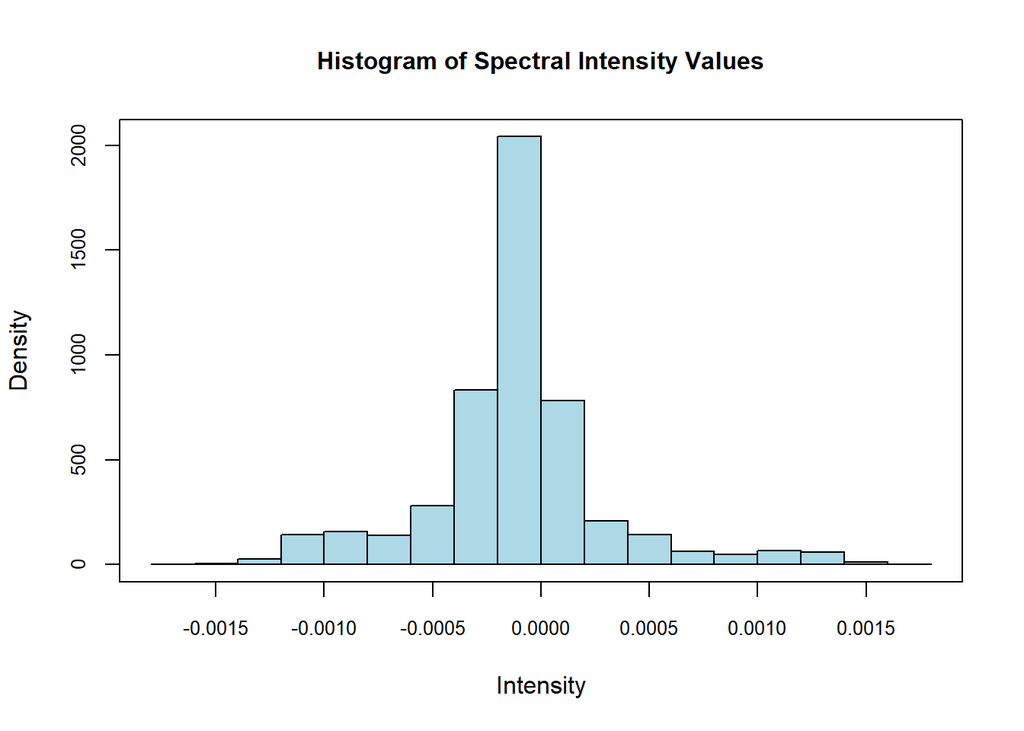

```r
hist(as.matrix(X), col = 'lightblue', cex.main = 1.0, cex.axis = 0.8,cex.lab = 1.0,freq = FALSE,
     main = 'Histogram of Spectral Intensity Values', xlab = 'Intensity'); box()
```

## Split the Data (Train_Test Split)

- We want to select features based on training data only to avoid any data leakage that could inflate model performance and make the model less generalizable to unseen data.

```r
# Subset samples for cross-validation and external validation (70/30)
# Record 1 under cal_val variable is for calibration while 2 will be for testing the model

sample<-hsi_msc_sg_2d$cal_val == 1

# Split to train and test sets
X_train <- X[sample,]
X_test <- X[!sample,]
y_train <-y[sample]
y_test <- y[!sample]

# Check length of the subsets for training and validation
dim(X_train)
```

```
[1] 1055  224
```

```r
dim(X_test)
```

```
[1] 414 224
```

```r
length(y_train)
```

```
[1] 1055
```

```r
length(y_test)
```

```
[1] 414
```

```r
# Merge the test and train data
train_data <- data.frame(y_train, X_train)
test_data <- data.frame(y_test, X_test)
```

## Train Models

```r
# Set random seed for reproducibility
set.seed (123)

# Set up the training control(10 folds 10 times cross_validation)
control <- trainControl(method = "repeatedcv", number = 10, repeats = 10,
                        savePredictions = "final",
                        summaryFunction = defaultSummary,
                        selectionFunction = 'best', allowParallel = TRUE)

# We used oneSE for classification. For regression, we will use 'best': a model that minimizes RMSECV
```

```r
#Set the metric as accuracy
metric<-"RMSE"
```

```r
# Hyperparameter set Elastic Net Regression
# alpha: Set for L1(elastic_net) and L2(Ridge) Regression
# lambda: Regularization strength (penalty parameter). A sequence of values is tested to identify the best lambda.

grid <- expand.grid( alpha = seq(0, 1, length = 10),  # Explore between Ridge (alpha = 0) and elastic_net (alpha = 1)
    lambda = seq(0.001, 0.1, length = 10))
```

# Train Elastic Net

```r
set.seed(123)
#Register cluster for caret to train the models in parallel
cl<-makeCluster(6,type = "SOCK")
suppressWarnings(suppressMessages(
  registerDoSNOW(cl)))

# Start_time
start_time<-Sys.time()

#Train the model using cross-validation (10 folds, 10 times)
fit_elastic_net_msc_sg_2d<-train(y = train_data[,1],
                         x = train_data[,-1],
                         method = 'glmnet', tuneGrid = grid,
                         trControl = control, preProcess = c("center","scale"),
                         metric = metric)
#End_time
end_time<-Sys.time()

model_training_time<-end_time-start_time

stopCluster(cl) # Stop the parallel run cluster

print(model_training_time)
```

```
Time difference of 3.613643 mins
```

```r
# Display regression results
print(fit_elastic_net_msc_sg_2d)
```

```
glmnet

1055 samples
 224 predictor

Pre-processing: centered (224), scaled (224)
Resampling: Cross-Validated (10 fold, repeated 10 times)
Summary of sample sizes: 949, 949, 949, 948, 949, 950, ...
Resampling results across tuning parameters:

  alpha      lambda  RMSE      Rsquared   MAE
  0.0000000  0.001   7.391980  0.9352503  5.858908
  0.0000000  0.012   7.391980  0.9352503  5.858908
  0.0000000  0.023   7.391980  0.9352503  5.858908
  0.0000000  0.034   7.391980  0.9352503  5.858908
  0.0000000  0.045   7.391980  0.9352503  5.858908
  0.0000000  0.056   7.391980  0.9352503  5.858908
  0.0000000  0.067   7.391980  0.9352503  5.858908
  0.0000000  0.078   7.391980  0.9352503  5.858908
  0.0000000  0.089   7.391980  0.9352503  5.858908
  0.0000000  0.100   7.391980  0.9352503  5.858908
  0.1111111  0.001   6.020095  0.9570481  4.749403
  0.1111111  0.012   6.020095  0.9570481  4.749403
  0.1111111  0.023   6.038707  0.9567777  4.762327
  0.1111111  0.034   6.107422  0.9557868  4.813067
  0.1111111  0.045   6.168519  0.9549021  4.858396
  0.1111111  0.056   6.221413  0.9541306  4.898565
  0.1111111  0.067   6.271903  0.9533866  4.938824
  0.1111111  0.078   6.318469  0.9526902  4.976925
  0.1111111  0.089   6.361526  0.9520444  5.012311
  0.1111111  0.100   6.403718  0.9514085  5.046087
  0.2222222  0.001   5.976938  0.9576694  4.720362
  0.2222222  0.012   5.990148  0.9574808  4.728430
  0.2222222  0.023   6.084422  0.9561338  4.793578
  0.2222222  0.034   6.169273  0.9549036  4.856975
  0.2222222  0.045   6.243131  0.9538179  4.913896
  0.2222222  0.056   6.316015  0.9527336  4.971492
  0.2222222  0.067   6.379277  0.9517773  5.022236
  0.2222222  0.078   6.439632  0.9508587  5.070205
  0.2222222  0.089   6.499012  0.9499464  5.115919
```

[output cut: 59 more lines]

```
  0.8888889  0.089   7.106489  0.9401057  5.602598
  0.8888889  0.100   7.195778  0.9385914  5.680538
  1.0000000  0.001   5.947236  0.9580896  4.703093
  1.0000000  0.012   6.159512  0.9550598  4.851577
  1.0000000  0.023   6.399780  0.9514802  5.039571
  1.0000000  0.034   6.581383  0.9486624  5.175296
  1.0000000  0.045   6.749511  0.9459799  5.304850
  1.0000000  0.056   6.886497  0.9437563  5.414623
  1.0000000  0.067   6.980814  0.9422090  5.493579
  1.0000000  0.078   7.084962  0.9404690  5.583205
  1.0000000  0.089   7.186325  0.9387527  5.671727
  1.0000000  0.100   7.261828  0.9374612  5.737117

RMSE was used to select the optimal model using the smallest value.
The final values used for the model were alpha = 1 and lambda = 0.001.
```

#### Best hyperparameters

```r
# Best lambda value
best_lambda <- fit_elastic_net_msc_sg_2d$bestTune$lambda

cat("Best Lambda:", best_lambda, "\n")
```

```
Best Lambda: 0.001
```

#### Extract Selected Features

```r
# Extract coefficients from the best model
coefficients <- coef(fit_elastic_net_msc_sg_2d$finalModel, s = best_lambda)

# Convert to a readable format
elastic_net_coefficients <- as.data.frame(as.matrix(coefficients))
colnames(elastic_net_coefficients) <- "Coefficient"
elastic_net_coefficients$Variable <- rownames(elastic_net_coefficients)

# Filter non-zero coefficients (selected features)
selected_features <- elastic_net_coefficients[elastic_net_coefficients$Coefficient != 0, ]
print(selected_features)
```

```
               Coefficient     Variable
(Intercept)   3.016019e+01  (Intercept)
X942.52002    8.884438e-02   X942.52002
X945.97998    9.693752e-01   X945.97998
X949.429993   3.731218e-14  X949.429993
X952.890015   7.872577e-01  X952.890015
X959.809998  -4.841690e-01  X959.809998
X963.27002   -8.231150e+00   X963.27002
X966.72998    6.319652e+00   X966.72998
X970.190002   3.767428e+00  X970.190002
X977.109985  -1.754066e+00  X977.109985
X980.580017   4.441888e-02  X980.580017
X984.039978   8.896849e-01  X984.039978
X987.51001    5.045372e-02   X987.51001
X990.969971  -1.846466e+00  X990.969971
X994.429993   3.036582e+00  X994.429993
X997.900024  -8.887202e-01  X997.900024
X1001.369995 -1.555264e+00 X1001.369995
X1004.830017  5.705879e-01 X1004.830017
X1011.77002  -5.405129e-02  X1011.77002
X1015.23999   4.707192e+00  X1015.23999
X1018.710022 -2.357861e+00 X1018.710022
X1022.179993 -1.958585e+00 X1022.179993
X1029.119995  3.710519e+00 X1029.119995
X1032.589966 -5.826592e-04 X1032.589966
X1036.060059 -2.335149e+00 X1036.060059
X1039.530029  5.952728e+00 X1039.530029
X1043         1.751361e+00        X1043
X1046.47998  -2.960766e-01  X1046.47998
X1049.949951 -3.467331e+00 X1049.949951
X1053.430054  4.681772e+00 X1053.430054
X1056.900024 -2.810935e+00 X1056.900024
X1060.380005  6.239972e+00 X1060.380005
X1063.849976 -4.557286e+00 X1063.849976
X1067.329956 -7.328462e-01 X1067.329956
X1070.810059  6.226324e-01 X1070.810059
X1074.290039 -6.989890e-01 X1074.290039
X1077.76001  -3.479302e-04  X1077.76001
X1081.23999   2.028480e+00  X1081.23999
X1084.719971  1.339247e+00 X1084.719971
```

[output cut: 129 more lines]

```
X1641.579956  5.936588e+00 X1641.579956
X1645.150024  8.810733e+00 X1645.150024
X1648.709961 -2.357432e-01 X1648.709961
X1652.290039 -1.147423e+01 X1652.290039
X1659.430054 -4.981505e+00 X1659.430054
X1663        -3.737379e-01        X1663
X1666.569946  5.034645e+00 X1666.569946
X1670.140015  1.935592e+01 X1670.140015
X1677.290039 -3.153334e-01 X1677.290039
X1680.869995 -3.045489e+00 X1680.869995
X1688.02002   8.930743e-03  X1688.02002
X1691.589966 -5.019336e+00 X1691.589966
X1698.75     -1.964003e-01     X1698.75
X1702.329956 -1.495708e-11 X1702.329956
X1705.910034 -7.479312e-12 X1705.910034
```

```r
# Sort the selected features by actual values in descending order
selected_features_sorted_actual <- selected_features[order(selected_features$Coefficient, decreasing = TRUE), ]

# Print the sorted features
print(selected_features_sorted_actual)
```

```
               Coefficient     Variable
(Intercept)   3.016019e+01  (Intercept)
X1442.599976  1.998230e+01 X1442.599976
X1670.140015  1.935592e+01 X1670.140015
X1126.52002   1.445493e+01  X1126.52002
X1439.069946  1.437102e+01 X1439.069946
X1343.780029  1.305505e+01 X1343.780029
X1400.199951  1.296085e+01 X1400.199951
X1336.73999   1.255577e+01  X1336.73999
X1361.390015  1.104673e+01 X1361.390015
X1602.349976  9.337684e+00 X1602.349976
X1645.150024  8.810733e+00 X1645.150024
X1357.869995  8.601662e+00 X1357.869995
X1545.420044  7.766226e+00 X1545.420044
X1140.469971  6.965052e+00 X1140.469971
X1573.869995  6.862110e+00 X1573.869995
X1623.73999   6.494170e+00  X1623.73999
X1312.109985  6.452024e+00 X1312.109985
X1298.050049  6.396706e+00 X1298.050049
X966.72998    6.319652e+00   X966.72998
X1060.380005  6.239972e+00 X1060.380005
X1333.219971  6.096708e+00 X1333.219971
X1039.530029  5.952728e+00 X1039.530029
X1641.579956  5.936588e+00 X1641.579956
X1308.589966  5.556514e+00 X1308.589966
X1109.099976  5.496404e+00 X1109.099976
X1287.51001   5.394585e+00  X1287.51001
X1666.569946  5.034645e+00 X1666.569946
X1492.180054  4.743159e+00 X1492.180054
X1015.23999   4.707192e+00  X1015.23999
X1053.430054  4.681772e+00 X1053.430054
X1175.390015  4.492187e+00 X1175.390015
X1595.22998   3.970423e+00  X1595.22998
X1102.130005  3.949867e+00 X1102.130005
X1182.380005  3.890046e+00 X1182.380005
X970.190002   3.767428e+00  X970.190002
X1513.459961  3.762375e+00 X1513.459961
X1029.119995  3.710519e+00 X1029.119995
X1147.449951  3.698545e+00 X1147.449951
X1168.400024  3.506073e+00 X1168.400024
```

[output cut: 129 more lines]

```
X1527.660034 -6.034553e+00 X1527.660034
X1584.550049 -6.161971e+00 X1584.550049
X1245.400024 -6.612944e+00 X1245.400024
X1227.869995 -7.206573e+00 X1227.869995
X1248.900024 -7.427392e+00 X1248.900024
X1238.390015 -8.018925e+00 X1238.390015
X1241.890015 -8.090906e+00 X1241.890015
X963.27002   -8.231150e+00   X963.27002
X1609.47998  -9.695172e+00  X1609.47998
X1252.410034 -1.062079e+01 X1252.410034
X1652.290039 -1.147423e+01 X1652.290039
X1319.140015 -1.251285e+01 X1319.140015
X1382.550049 -1.374152e+01 X1382.550049
X1634.439941 -1.396639e+01 X1634.439941
X1538.319946 -1.763997e+01 X1538.319946
```

```r
print(paste('The number of feautures selected by elastic_net are', nrow(selected_features_sorted_actual)))
```

```
[1] "The number of feautures selected by elastic_net are 183"
```

## Save the models for future use

```r
saveRDS(fit_elastic_net_msc_sg_2d, "fit_elastic_net_msc_sg_2d.rds")
```

#### Coefficients vs. Lambda Path

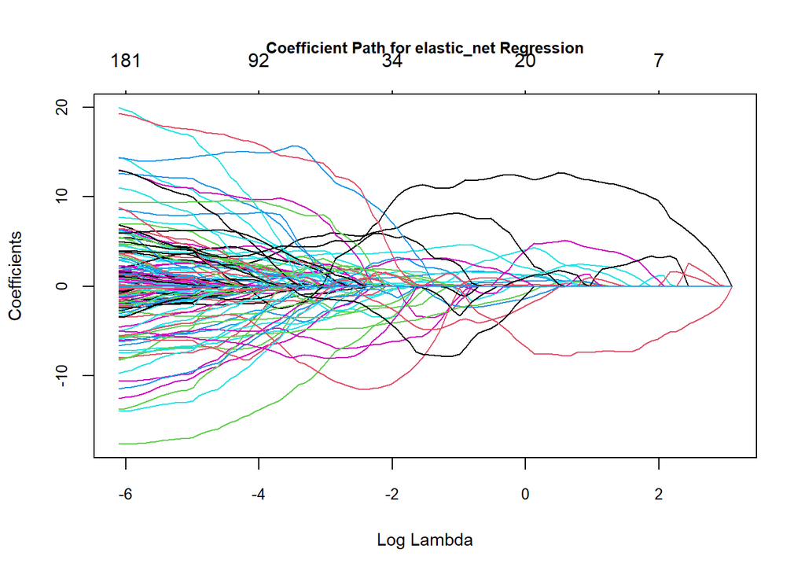

```r
# Extract the final glmnet model
fit_glmnet <- fit_elastic_net_msc_sg_2d$finalModel

# Plot coefficients vs. lambda
par(cex.main = 0.8)
plot(
  fit_glmnet,
  xvar = "lambda",
  label = FALSE,
  cex.axis = 0.8,
  cex.lab = 0.9,
  cex.main = 0.3)
title(main = "Coefficient Path for elastic_net Regression")
```

```r
#As lambda increases, coefficients shrink toward zero, highlighting the feature selection process
```

## Display CV Results in Tables

```r
kable(fit_elastic_net_msc_sg_2d$results)
```

| alpha | lambda | RMSE | Rsquared | MAE | RMSESD | RsquaredSD | MAESD |
| --- | --- | --- | --- | --- | --- | --- | --- |
| 0.0000000 | 0.001 | 7.391980 | 0.9352503 | 5.858908 | 0.5728642 | 0.0087144 | 0.4307227 |
| 0.0000000 | 0.012 | 7.391980 | 0.9352503 | 5.858908 | 0.5728642 | 0.0087144 | 0.4307227 |
| 0.0000000 | 0.023 | 7.391980 | 0.9352503 | 5.858908 | 0.5728642 | 0.0087144 | 0.4307227 |
| 0.0000000 | 0.034 | 7.391980 | 0.9352503 | 5.858908 | 0.5728642 | 0.0087144 | 0.4307227 |
| 0.0000000 | 0.045 | 7.391980 | 0.9352503 | 5.858908 | 0.5728642 | 0.0087144 | 0.4307227 |
| 0.0000000 | 0.056 | 7.391980 | 0.9352503 | 5.858908 | 0.5728642 | 0.0087144 | 0.4307227 |
| 0.0000000 | 0.067 | 7.391980 | 0.9352503 | 5.858908 | 0.5728642 | 0.0087144 | 0.4307227 |
| 0.0000000 | 0.078 | 7.391980 | 0.9352503 | 5.858908 | 0.5728642 | 0.0087144 | 0.4307227 |
| 0.0000000 | 0.089 | 7.391980 | 0.9352503 | 5.858908 | 0.5728642 | 0.0087144 | 0.4307227 |
| 0.0000000 | 0.100 | 7.391980 | 0.9352503 | 5.858908 | 0.5728642 | 0.0087144 | 0.4307227 |
| 0.1111111 | 0.001 | 6.020095 | 0.9570481 | 4.749403 | 0.4181381 | 0.0056231 | 0.3532275 |
| 0.1111111 | 0.012 | 6.020095 | 0.9570481 | 4.749403 | 0.4181381 | 0.0056231 | 0.3532275 |
| 0.1111111 | 0.023 | 6.038707 | 0.9567777 | 4.762327 | 0.4218879 | 0.0056899 | 0.3557042 |
| 0.1111111 | 0.034 | 6.107422 | 0.9557868 | 4.813067 | 0.4304217 | 0.0058485 | 0.3599625 |
| 0.1111111 | 0.045 | 6.168519 | 0.9549021 | 4.858396 | 0.4362704 | 0.0059581 | 0.3639512 |
| 0.1111111 | 0.056 | 6.221413 | 0.9541306 | 4.898565 | 0.4417679 | 0.0060550 | 0.3667645 |
| 0.1111111 | 0.067 | 6.271903 | 0.9533866 | 4.938824 | 0.4454213 | 0.0061170 | 0.3683514 |
| 0.1111111 | 0.078 | 6.318469 | 0.9526902 | 4.976925 | 0.4488200 | 0.0061952 | 0.3703269 |
| 0.1111111 | 0.089 | 6.361526 | 0.9520444 | 5.012311 | 0.4554789 | 0.0063080 | 0.3747772 |
| 0.1111111 | 0.100 | 6.403718 | 0.9514085 | 5.046087 | 0.4594495 | 0.0063618 | 0.3757508 |
| 0.2222222 | 0.001 | 5.976938 | 0.9576694 | 4.720362 | 0.4037180 | 0.0054217 | 0.3446119 |
| 0.2222222 | 0.012 | 5.990148 | 0.9574808 | 4.728430 | 0.4058873 | 0.0054478 | 0.3466414 |
| 0.2222222 | 0.023 | 6.084422 | 0.9561338 | 4.793578 | 0.4221407 | 0.0057037 | 0.3545728 |
| 0.2222222 | 0.034 | 6.169272 | 0.9549036 | 4.856975 | 0.4340575 | 0.0059194 | 0.3612785 |
| 0.2222222 | 0.045 | 6.243131 | 0.9538179 | 4.913896 | 0.4438613 | 0.0060940 | 0.3682566 |
| 0.2222222 | 0.056 | 6.316015 | 0.9527336 | 4.971492 | 0.4510769 | 0.0062098 | 0.3725684 |
| 0.2222222 | 0.067 | 6.379277 | 0.9517773 | 5.022236 | 0.4574207 | 0.0063306 | 0.3756173 |
| 0.2222222 | 0.078 | 6.439632 | 0.9508587 | 5.070206 | 0.4631119 | 0.0064311 | 0.3782804 |
| 0.2222222 | 0.089 | 6.499012 | 0.9499464 | 5.115919 | 0.4686967 | 0.0065388 | 0.3810302 |
| 0.2222222 | 0.100 | 6.548598 | 0.9491791 | 5.153466 | 0.4727442 | 0.0066148 | 0.3842505 |

[output cut: 70 more lines]

```r
# Select row for the optimal model
opt_row <- fit_elastic_net_msc_sg_2d$results %>%
  filter(lambda==fit_elastic_net_msc_sg_2d$bestTune$lambda)

kable(opt_row)
```

| alpha | lambda | RMSE | Rsquared | MAE | RMSESD | RsquaredSD | MAESD |
| --- | --- | --- | --- | --- | --- | --- | --- |
| 0.0000000 | 0.001 | 7.391980 | 0.9352503 | 5.858908 | 0.5728642 | 0.0087144 | 0.4307227 |
| 0.1111111 | 0.001 | 6.020095 | 0.9570481 | 4.749403 | 0.4181381 | 0.0056231 | 0.3532275 |
| 0.2222222 | 0.001 | 5.976938 | 0.9576694 | 4.720362 | 0.4037180 | 0.0054217 | 0.3446119 |
| 0.3333333 | 0.001 | 5.958667 | 0.9579212 | 4.709002 | 0.4096065 | 0.0054858 | 0.3482906 |
| 0.4444444 | 0.001 | 5.966432 | 0.9578232 | 4.714743 | 0.4066245 | 0.0054433 | 0.3459920 |
| 0.5555556 | 0.001 | 5.962910 | 0.9578625 | 4.711720 | 0.4112258 | 0.0055427 | 0.3453187 |
| 0.6666667 | 0.001 | 5.959685 | 0.9579199 | 4.714068 | 0.4043496 | 0.0053856 | 0.3421842 |
| 0.7777778 | 0.001 | 5.969137 | 0.9578005 | 4.721998 | 0.4116931 | 0.0055094 | 0.3441386 |
| 0.8888889 | 0.001 | 5.958021 | 0.9579435 | 4.710311 | 0.4046856 | 0.0053811 | 0.3424096 |
| 1.0000000 | 0.001 | 5.947236 | 0.9580896 | 4.703093 | 0.4012015 | 0.0053614 | 0.3432493 |

## Test the model performance on test data

```r
#Predict on the test set
observed <- test_data$y_test
predictions <- predict(fit_elastic_net_msc_sg_2d,newdata=test_data)

# Generate predictions
results <- postResample(predictions, observed)

print(results)
```

```
     RMSE  Rsquared       MAE
7.9197051 0.9337763 6.3244353
```

```r
RMSEP = results[[1]]
R2 = results[[2]]
MAE = results[[3]]

cat('The RMSEP for the model on external validation is:', RMSEP,'\n')
```

```
The RMSEP for the model on external validation is: 7.919705
```

```r
cat('The R Squared value for the model is:', R2)
```

```
The R Squared value for the model is: 0.9337763
```

```r
# Calculate Residual Predictive Deviation to check model performance

RPD = sd(observed)/RMSEP

print(paste('The RPD values for the model is', round(RPD,2)))
```

```
[1] "The RPD values for the model is 3.68"
```

## Visualizations

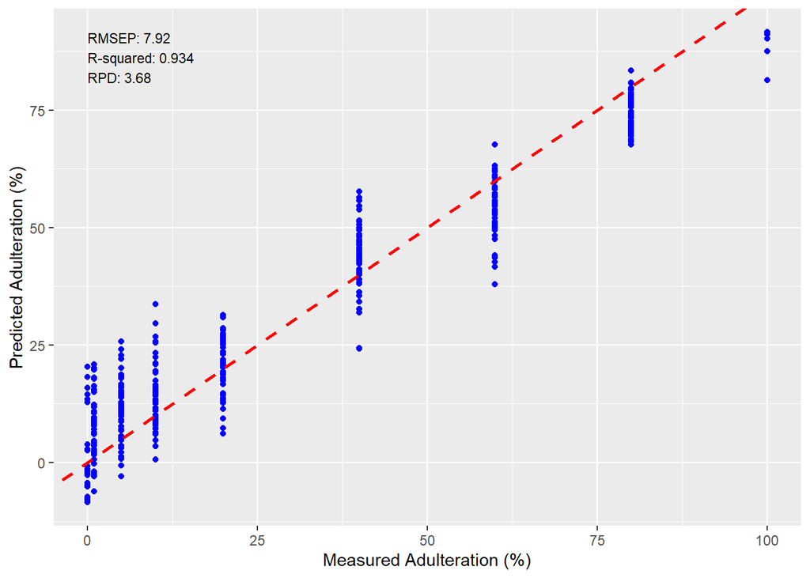

```r
# predicted vs observed line and scatter
# Create a data frame
results_df <- data.frame(observed=observed, predictions=predictions)

results_df %>%
  ggplot(aes(x = observed, y = predictions)) +
  geom_point(color = "blue") +
  geom_abline(slope = 1, intercept = 0, color = "red",
              linetype = "dashed", linewidth = 1) +
  labs( x = "Measured Adulteration (%)",
    y = "Predicted Adulteration (%)") +
  annotate("text",
    x = min(observed), y = max(predictions),
    label = paste("RMSEP:", round(RMSEP, 2),
      "\nR-squared:", round(R2, 3),
      "\nRPD:", round(RPD, 2)),
    hjust = 0, vjust = 1, size = 3, color = "black") +
  theme(
    axis.title = element_text(color = "black", size = 10),
    axis.text = element_text(color = "black"))+
  theme_gray()
```

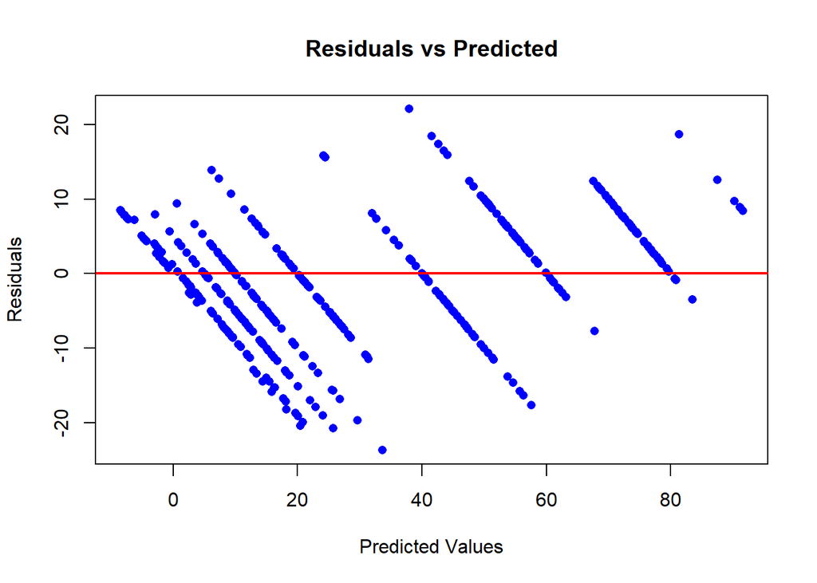

```r
# Check residuals

residuals <- observed - predictions

# Plot Residuals
plot(predictions, residuals,
     xlab = "Predicted Values",
     ylab = "Residuals",
     main = "Residuals vs Predicted",
     pch = 16, col = "blue")
abline(h = 0, col = "red", lwd = 2)
```

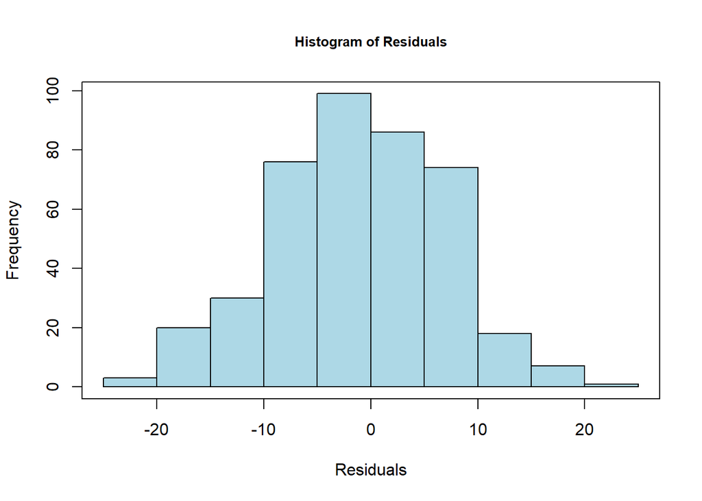

```r
hist(residuals,
     main = "Histogram of Residuals",
     xlab = "Residuals", cex.main = 0.8,
     col = "lightblue", border = "black"); box()
```

## Conclusion

- Elastic_net demonstrate excellent performance in predicting adulteration in ground coffee. The model achieves an RPD value of 3.7. The model can make reliable predictions and is suitable for quality control.